# R Notebook

# Specializing Noise

A principle benefit of the drifting array is it’s ability to cover a considerable distance over the short deployment duration. In this portion of the report we ask whether it’s possible to create a noise map of the area.

The primary challenge in addressing this question is decoupling the space and time components as the units drift. Consider that the low frequency domain is dominated by atmospheric signals, shipping, and the calls of very loud animals including fin and blue whales. These sounds propagate tens to hundreds of miles resulting in highly correlated ambient noise metrics in time.

Lets first load the data and plot what we see.

```r
rm(list = ls())
library(mgcv)
library(dplyr)
library(lubridate)
library(viridis)
library(ggplot2)

load('Adrift_GPS_2023.rds')
load('Adrift_NL_2023_500Hz.rds')

# Link the gps and the noise levels
noiseDf$Lon = NaN
noiseDf$Lat = NaN

DriftNames = unique(GPSdf$DriftName)
GPSdf$NL<- NaN

for(drift in DriftNames){
  GPSsub = subset(GPSdf, DriftName == drift)
  NLsub =  subset(noiseDf, DriftName==drift)

  UTMflon <- approxfun(GPSsub$UTC, GPSsub$Longitude)
  UTMflat <- approxfun(GPSsub$UTC, GPSsub$Latitude)
  NLf<-approxfun(NLsub$datetime_posix, NLsub$TOL_500, na.rm = TRUE)

  ##############################################################
  # Calculate the range from the whale to the GPS, TDOA and RL
  ############################################################

  # Lat/lon/ of the drift when the call was produced
  noiseDf$Lon[noiseDf$DriftName==drift] =UTMflon(NLsub$datetime_posix)
  noiseDf$Lat[noiseDf$DriftName==drift] = UTMflat(NLsub$datetime_posix)
  GPSdf$NL[GPSdf$DriftName==drift] <-NLf(GPSsub$UTC)
}

colnames(noiseDf)[2]<-'NL'

# Clear out any NA values
noiseDf = noiseDf[!is.na(noiseDf$Lat),]

# add seconds since start as an integer for the gam
noiseDf$seconds = as.numeric(noiseDf$datetime_posix-median(noiseDf$datetime_posix))

# there are some duplicated values for some reason.
duplicatedIdx = which(duplicated(noiseDf$Lon))
noiseDf$Lon[duplicatedIdx]=noiseDf$Lon[duplicatedIdx]+
  rnorm(n = length(duplicatedIdx))/1000
noiseDf$Lat[duplicatedIdx]=noiseDf$Lat[duplicatedIdx]+
  rnorm(n = length(duplicatedIdx))/1000

duplicatedIdx = which(duplicated(GPSdf$Lon))
GPSdf$Lon[duplicatedIdx]=GPSdf$Lon[duplicatedIdx]+
  rnorm(n = length(duplicatedIdx))/1000
GPSdf$Lat[duplicatedIdx]=GPSdf$Lat[duplicatedIdx]+
  rnorm(n = length(duplicatedIdx))/1000



# Load the wind lease area
# Load the wind lease area
library(sf)
WLA <- st_read(
  "F:\\GPS_CSV-20230923T045356Z-001\\MorroBay_WEA_2021_11_12.shp")
WLA = as.data.frame(WLA[[6]][[1]][1])
colnames(WLA)<-c('UTMx','UTMy')

# Add lat/lon
# Add UTC coords with the sp package
cord.dec = SpatialPoints(cbind(WLA$UTMx,WLA$UTMy),
                         proj4string=CRS("+init=epsg:32610"))


cord.dec = spTransform(cord.dec, CRS("+proj=longlat"))
WLA$Lon =  coordinates(cord.dec)[,1]
WLA$Lat =  coordinates(cord.dec)[,2]


ggplot(GPSdf)+
  geom_point(aes(x=Lon, y=Lat, color=NL))+
  scale_color_viridis_c(option='plasma')
```

[output not shown]

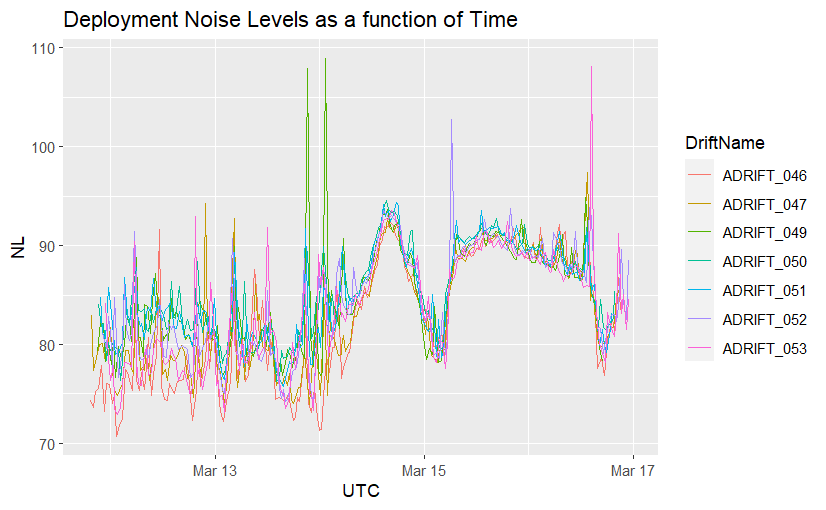

```r
 ggplot(GPSdf)+
   geom_line(aes(x= UTC, y=NL, color= DriftName))+
   ggtitle('Deployment Noise Levels as a function of Time')
```

This figure demonstrates the varying timescales acting on the ambient noise levels without doing much fancy. Large-scale events such as storms impact the entire array (regardless of location) and smaller scale events effect locations differently. We cannot then assume that background noise was stationary in time, we must account for temporal variation in some way.

The simplest method of addressing the large scale events is to simply subtract the hourly median noise level from all the events. This will then leave us with relative noisiness. The below code calculates the median and plots the normalized noise levels.

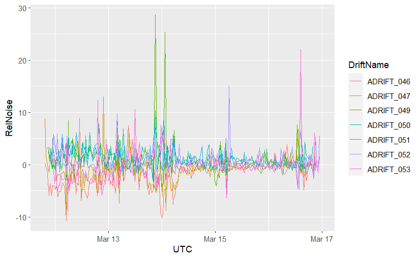

```r
# Calculate the median hourly noise level for each DriftName, day, and hour
median_hourly_noise<- noiseDf %>%
  group_by(Date = date(datetime_posix), Hour = hour(datetime_posix)) %>%
  summarise(medianNL = median(NL, na.rm = TRUE))
noiseDf$Date = date(noiseDf$datetime_posix)
noiseDf$Hour = hour(noiseDf$datetime_posix)

# Merge the median hourly noise back to the original data frame
noiseDf <- noiseDf %>%
  left_join(median_hourly_noise, by = c( "Date", "Hour"))

# Find differences in noise levels and replot
noiseDf$RelNoise = noiseDf$NL- noiseDf$medianNL

# Larger scale, crashes R, modelling will be done using the smaller grid
#ggplot(noiseDf)+ geom_line(aes(x= datetime_posix, y=RelNoise, color= DriftName))

# But also this dataframe is huge so lets look at the same using only the GPS locations which will making the modelling tennable
GPSdf$Date = date(GPSdf$UTC)
GPSdf$Hour = hour(GPSdf$UTC)
GPSdf <- GPSdf %>%
  left_join(median_hourly_noise, by = c( "Date", "Hour"))

GPSdf$RelNoise = GPSdf$NL- GPSdf$medianNL

ggplot(GPSdf)+
  geom_line(aes(x= UTC, y=RelNoise, color= DriftName))
```

That looks much more reasonable. Now we can see that there was actually considerable variation in noise level at the start of the study, when the units were more north, than later in the deployment. We can, and should, no plot this on our deployment map.

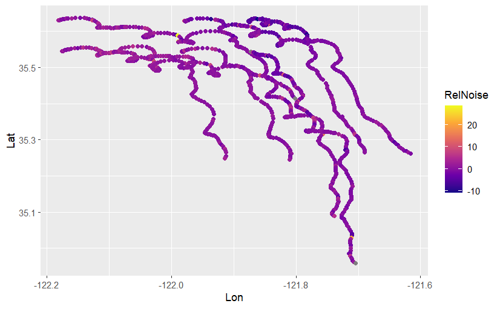

```r
ggplot(GPSdf)+
  geom_point(aes(x=Lon, y=Lat, color=RelNoise))+
  scale_color_viridis_c(option='plasma')
```

```r
NA
```

We can now use the fields package to fit both the raw data and the normalized noise levels to a surface.

[figure not shown]

“A variogram is a description of the spatial continuity of the data. The experimental variogram is a discrete function calculated using a measure of variability between pairs of points at various distances.”

```r
look1<-vgram( loc, GPSdf$NL, N=15, lon.lat=TRUE, type="covariogram")
```

```
Error in nrow(loc) : object 'loc' not found
```

Last we can use the fields package to look at model uncertainty.

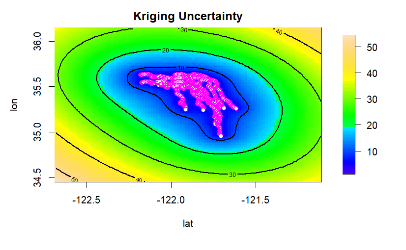

```r
grid.list <- list(lat=seq(min(GPSdf$Lon)-.5,max(GPSdf$Lon)+.5, length.out =100),
                  lon=seq(min(GPSdf$Lat)-.5,max(GPSdf$Lat)+.5, length.out =100))
full.grid <- make.surface.grid(grid.list)

SEobs <- predictSE.mKrig(obj)
SEout <- predictSE(obj, xnew=full.grid)

lookSE <- as.surface(full.grid, SEout)
{surface(lookSE,col=topo.colors(100))
title("Kriging Uncertainty")
points(loc[,1],loc[,2],col="magenta",bg="white",pch=21)}
```

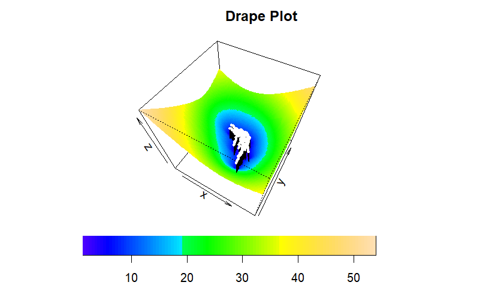

```r
{drape.plot(lookSE, border=NA, aRange=160, phi=55,col=topo.colors(100)) -> dp2
title("Drape Plot")
pushpin(loc[,1],loc[,2],SEobs,dp2, cex=0.4, col="white")}
```

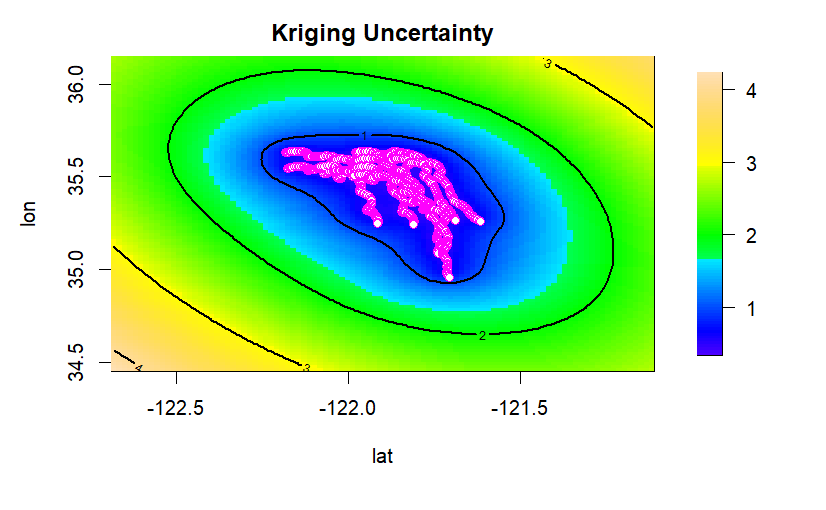

```r
SEobs.norm <- predictSE.mKrig(obj.norm)
SEout.norm <- predictSE(obj.norm, xnew=full.grid)

lookSE.norm <- as.surface(full.grid, SEout.norm)
{surface(lookSE.norm,col=topo.colors(100))
title("Kriging Uncertainty")
points(loc[,1],loc[,2],col="magenta",bg="white",pch=21)}
```

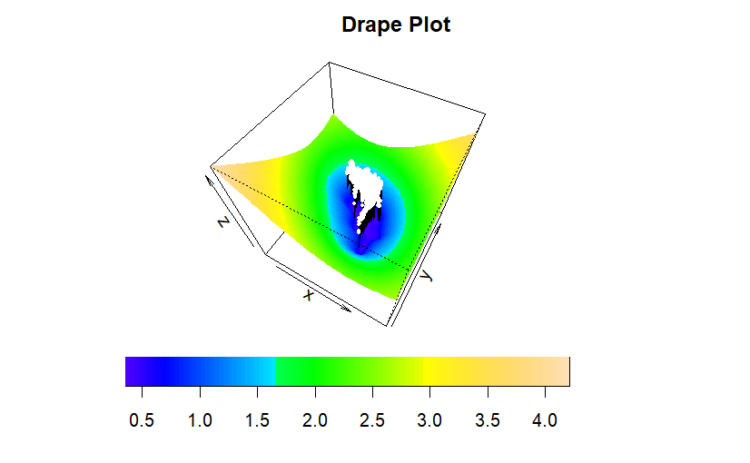

```r
{drape.plot(lookSE.norm, border=NA, phi=55,col=topo.colors(100)) -> dp2
title("Drape Plot")
pushpin(loc[,1],loc[,2],SEobs,dp2, cex=0.4, col="white")}
```

Last, lets do the same thing for some higher frequencies

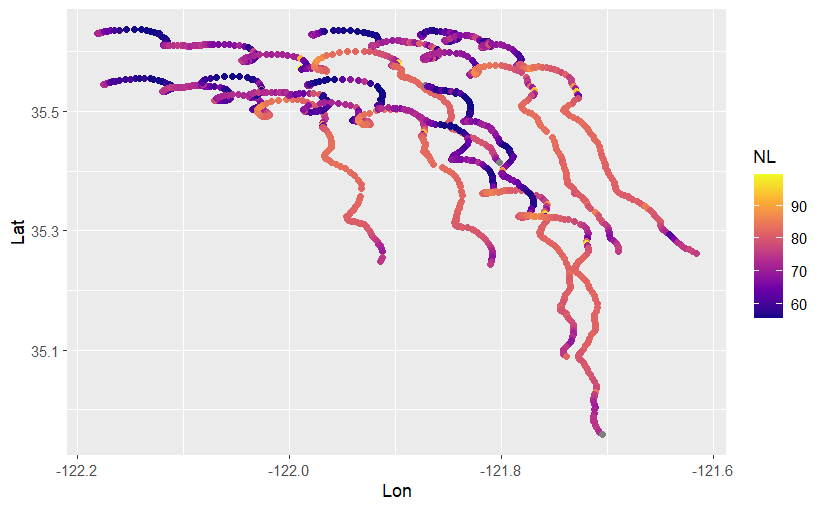

```r
library(here)
# Add noise level data
csv_directory='MorroBay Mar 2023 Noise Files'
csv_files <- list.files(path = csv_directory, pattern = "*.csv", full.names = TRUE)
dataframes_list <- list()

# Loop through each CSV file load, change name
for (csv_file in csv_files) {
  # Read the CSV file
  df <- read.csv(csv_file, header = TRUE)

  # Extract the first and eighth columns
  df <- df[, c("yyyy.mm.ddTHH.MM.SSZ", 'TOL_16000')]
  colnames(df)<-c('UTC', 'NL')

  # Extract the first 10 characters from the filename
  file_name <- substr(basename(csv_file), 1, 10)

  # Create a 'DriftName' column with the extracted filename
  df$DriftName <- file_name

  # Append the dataframe to the list
  dataframes_list[[file_name]] <- df
}

# Combine all dataframes into a single dataframe
noiseDf <- bind_rows(dataframes_list)
noiseDf$datetime_posix <- as.POSIXct(noiseDf$UTC,
                                     format = "%Y-%m-%dT%H:%M:%OSZ",
                                     tz='UTC')

for(drift in DriftNames){
  GPSsub = subset(GPSdf, DriftName == drift)
  NLsub =  subset(noiseDf, DriftName==drift)

  UTMflon <- approxfun(GPSsub$UTC, GPSsub$Longitude)
  UTMflat <- approxfun(GPSsub$UTC, GPSsub$Latitude)
  NLf<-approxfun(NLsub$datetime_posix, NLsub$NL, na.rm = TRUE)

  ##############################################################
  # Calculate the range from the whale to the GPS, TDOA and RL
  ############################################################

  # Lat/lon/ of the drift when the call was produced
  noiseDf$Lon[noiseDf$DriftName==drift] =UTMflon(NLsub$datetime_posix)
  noiseDf$Lat[noiseDf$DriftName==drift] = UTMflat(NLsub$datetime_posix)
  GPSdf$NL[GPSdf$DriftName==drift] <-NLf(GPSsub$UTC)
}

colnames(noiseDf)[2]<-'NL'

# Clear out any NA values
noiseDf = noiseDf[!is.na(noiseDf$Lat),]

# add seconds since start as an integer for the gam
noiseDf$seconds = as.numeric(noiseDf$datetime_posix-median(noiseDf$datetime_posix))

# there are some duplicated values for some reason.
duplicatedIdx = which(duplicated(noiseDf$Lon))
noiseDf$Lon[duplicatedIdx]=noiseDf$Lon[duplicatedIdx]+
  rnorm(n = length(duplicatedIdx))/1000
noiseDf$Lat[duplicatedIdx]=noiseDf$Lat[duplicatedIdx]+
  rnorm(n = length(duplicatedIdx))/1000

duplicatedIdx = which(duplicated(GPSdf$Lon))
GPSdf$Lon[duplicatedIdx]=GPSdf$Lon[duplicatedIdx]+
  rnorm(n = length(duplicatedIdx))/1000
GPSdf$Lat[duplicatedIdx]=GPSdf$Lat[duplicatedIdx]+
  rnorm(n = length(duplicatedIdx))/1000

ggplot(GPSdf)+
  geom_point(aes(x=Lon, y=Lat, color=NL))+
  scale_color_viridis_c(option='plasma')
```

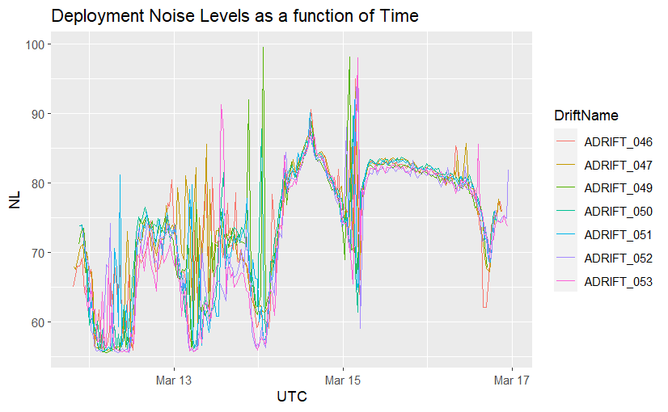

```r
ggplot(GPSdf)+
   geom_line(aes(x= UTC, y=NL, color= DriftName))+
   ggtitle('Deployment Noise Levels as a function of Time')
```

This has been a relatively quick look at how we can specialize our noise metrics. There is much more than can and should be done. However, for the purpose of the report I think there is maybe one or two more things worth investigating including estimating the predictive power of the method.

Predictive power

1. Knock out one or more of the sensors
2. Fit the field models
3. Used the field models to predict the levels at the knocked-out location
4. Estimate the error
5. Do this for one or more knockouts